# Project 6

Covid-19 data

Sciper 359523

# 1 Introduction

The covid-19 pandemic which started in December 2019 in Wuhan had a significant impact on the world, with over 160 million confirmed cases and 3.3 million deaths worldwide as of May 2023. The disease has been studied extensively in various fields, including epidemiology, medicine, and public health, and many models have been proposed. Some were based on theoretical models (SIR, SEIR, SEIRD…) and fitted to the data by estimating the models parameters. Another way of modelling the problem is to base the analysis on the data itself and not a general model, which has been proposed by Marc Lavielle [1], by detecting changing points in the derivative of the number of hospitalized patients, and then fitting polynomial regressions. In this project, we want to explore the pandemic’s amplitude variation with pca. To this end, we must consider the fact that countries were not impacted at the same time by the virus and thus synchronize the countries in a different time scale.

We will begin by introducing the data collection and its characteristics and then ways to smooth it and synchronize curves. Next, we will perform functional pca on the smoothed data. Finally, we will interpret the results.

# 2 Data collection and characteristics

In this project, the data used was collected from the website *OurWorldInData* [2], which compiles data on COVID-19 from the World Health Organization. I extracted the values from the original dataset corresponding to European countries with available COVID-19 data. The final dataset includes two categories of indicators: COVID-19 indicators and country characteristics. The COVID-19 indicators include the country, date, cumulative number of cases per million, and stringency index. The country characteristics include population, GDP per capita, and various health indicators, such as diabetes prevalence and the number of cardiovascular deaths. The full list of indicators, separated by category, is provided above for reference.

## 2.1 Covid-19 indicators

- Country
- Date
- Cumulative number of cases per million
- Stringency index

## 2.2 Countries characteristics

- Demographic indicators(population, population density, median age, percentage of people older than 65 years old, and the percentage of people older than 70 years old, life expectancy, human development index)
- Economic indicators(gdp per capita, extreme poverty proportion of people)
- Health indicators (number of cardiovascular deaths, diabetes prevalence,excess mortality, share of smoking women/men)
- Hospital beds per thousand

One can visualize the evolution of the logarithm of the cumulated cases (per million) on *Figure 1* for the whole period of the data.

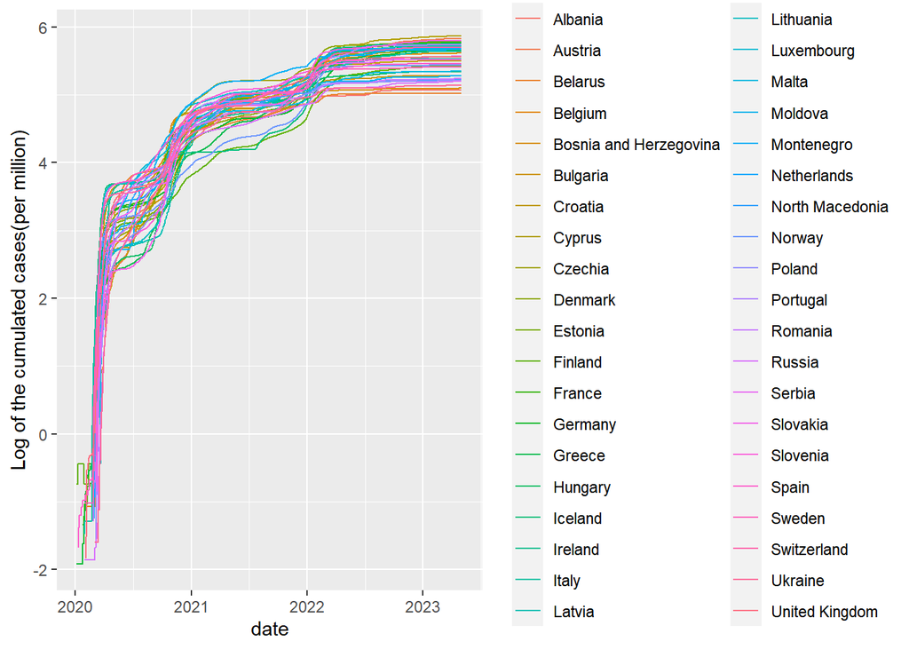

Figure 1: Number of cases accross the different countries

The cumulative number of cases for all European countries in the dataset are increasing since new cases are being added regularly. The shape of the curves is not linear, but rather appears to have wave tendencies. This is likely due to the waves of the pandemic and corresponding lockdown restrictions. Several studies have reported similar observations. For example, a study conducted by Pascual et al. (2021) [3] found that the pandemic spread in waves, with each wave potentially triggered by changes in human mobility or social behavior. The study also noted that the duration and amplitude of each wave varied across countries and regions. These findings suggest that the wave tendencies observed in the dataset may reflect broader patterns of pandemic spread and control.

In *Figure 2*, when examining the daily new cases, a weekly trend is apparent with a decrease over the weekends and a subsequent increase on Mondays. This pattern is likely due to reporting delays and issues in hospitals during the weekend. However, this may pose challenges when conducting further analysis, such as principal component analysis (PCA), as the trend could introduce noise and distortions in the data. To mitigate this issue, we plan to smooth the curve using rolling means and kernel estimation techniques. Rolling means calculate the average value of a subset of adjacent data points, while kernel estimation fits a smooth curve to the data by applying a mathematical function to each point and its surrounding neighbors. These techniques can help us better capture the underlying trends in the data and remove any noise or distortions caused by the reporting delays.

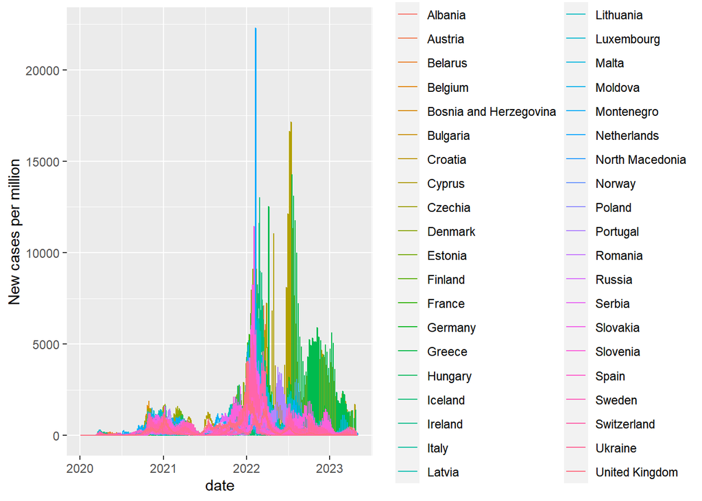

Figure 2: Number of new cases accross the different countries

# 3 Data modification

## 3.1 Method 1

One approach I consider is to first smooth the data and then align the curves by setting a common starting point based on a specific number of cases. Each country will have a fixed number of observations, but they will not end at the same time since they don’t start at the same time.

### 3.1.1 Smoothing

As a first approach of effectively smooth the data, I have considered two methods: the rolling mean with a 7-day window to address reporting issues during weekends, and the normal kernel smoothing technique using a 7-day window. Both methods yield valid and closely aligned results, but after careful consideration, I have decided to retain the series smoothed with the rolling mean approach.

The primary advantage of rolling mean over kernel smoothing lies in its simplicity and computational efficiency. Rolling mean can be seen as a specific instance of kernel smoothing, where the function used is the uniform density. This means that it corresponds to calculating the average of a sequence of data points within a fixed window. The simplicity and interpretability of rolling mean make it easier to comprehend and compute compared to normal kernel smoothing.

However, it’s worth noting that kernel smoothing offers the flexibility to assign different weights to observations, making it more robust against extreme values. In this specific case, since both methods yield similar results, I have opted for the rolling mean due to its simplicity.

### 3.1.2 Shifting the curves

Previously, we applied smoothing techniques to the curves; however, they are currently not synchronized, requiring us to adjust their alignment. I have established a threshold based on the number of accumulated cases. Once a country surpasses this threshold, I redefine the time scale, ensuring that all curves start at that specific time. Consequently, the curves are shifted to commence together when they have reached a similar stage in the pandemic’s progression. The outcomes of this alignment can be observed in *Figure 3*.

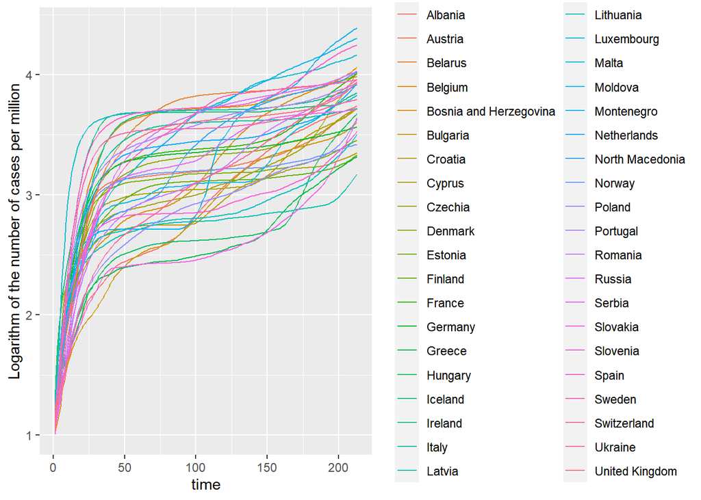

Figure 3: Shifted and smoothed curves - method 1

The alignment of the curves successfully ensures that they start at the same time and exhibit a similar trend simultaneously. However, it is important to note that variations in their evolution still persist, as evidenced by the lack of complete synchronization in the peaks. Moreover, I had to truncate some values which in the end which doesn’t seem a good idea. In the next subsection, I implement another method.

## 3.2 Method 2

The second method I consider is to first synchronize my curves and then smooth it with B splines.

### 3.2.1 Shifting the curves

To ensure consistency among the curves, I aim to align them while preserving all data points up until the specified limit of November 1, 2020. To achieve this, I normalize the time scale, representing the entire study period as the interval [0,1]. Here, 0 corresponds to the individual starting points (which vary across countries), and 1 represents the fixed end point of November 1, 2020, common to all countries.

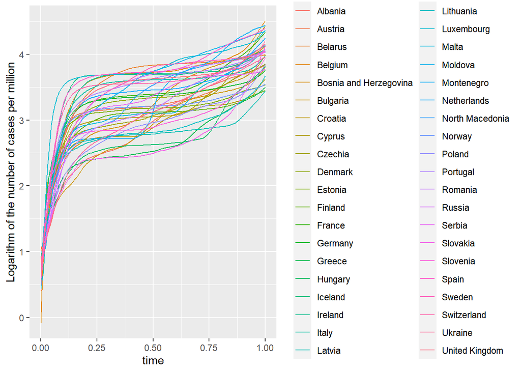

Figure 4: Shifted curves - method 2

### 3.2.2 Smoothing

I don’t have the same amount of observations for each country and I have not yet smoothed my data so I use the B-splines to do so. I have almost 250 values for each country, so I decide to do evaluate my B-splines on 150 final values. After smoothing, I obtain *Figure 5*.

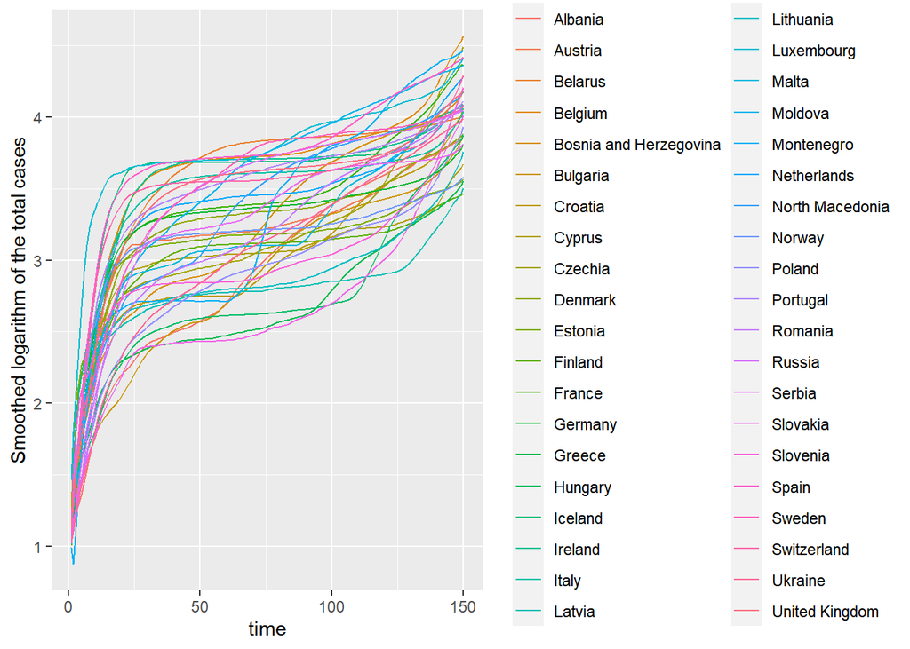

Figure 5: Shifted and smoothed curves - method 2

Another intriguing approach for shifting the curves would have been by following Marc Lavielle’s procedure [1]. In his article, Lavielle utilizes the logarithmic derivative (u’/u) of the number of daily cases to identify critical breaking points in the curve. These breaking points play a significant role in determining the pandemic’s progression towards a peak or a decline in the number of cases. By selecting and aligning the breaking points, it becomes possible to shift the curves together, ensuring that the breaking points coincide. However, this method would probably fail in this case because of the fact that governments influenced the pandemic’s evolution in different ways. Indeed, the lockdowns were not of the same intensity in all the countries, and even some Nordic countries did not choose to confine their population.

# 4 PCA

## 4.1 With the 1st method

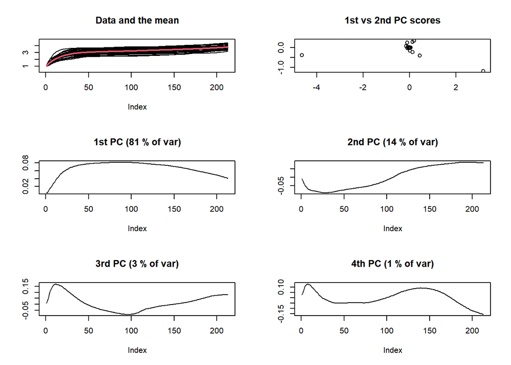

Figure 5: PCA curves with method 1

## 4.2 With the 2nd method

I represent in *Figure 6* the PCA obtained with the second method.

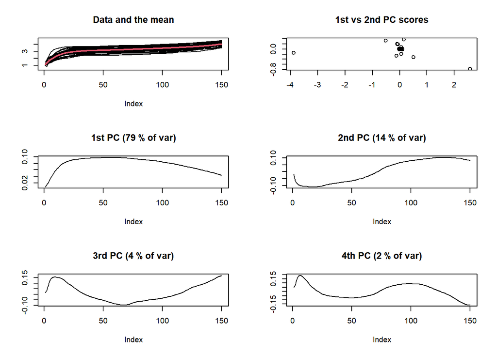

Figure 6: PCA curves with method 2

# 5 Interpretation

The second principal component analysis obtained with method 2 reveals that the first principal component also accounts for 79% of the total variance and is really close to what I had obtained with method 1. The second principal component analysis accounts now for 14% of the variance, whereas the third and fourth account for 6%. In total the first four PC account for 99% of the variance.

# 6 Discussion

In this project, our main focus was to analyze and explain the amplitude of data representing the logarithm of cumulative COVID-19 cases in European countries within a specific time period. Given the spread of the pandemic, countries experienced variations in the timing of case numbers and deaths, resulting in lagged evolutions.

To address this time shift, we adjusted the curves by synchronizing them, enabling us to conduct a more accurate principal component analysis (PCA). By considering the curves’ alignment, with method 1, we were able to obtain the four leading principal components, which accounted for 99% of the total variance. Notably, the first principal component explained 81% of the variance and effectively captured the initial peak experienced by the countries. However, it is important to acknowledge that factors such as countries’ demographics and political measures can significantly influence the pandemic’s evolution. This complexity limits the effectiveness of our simple curve-shifting method, which assumes linear time progression.

With the second method which also addresses the issue of the time shift, the PCA gives similar results with close explanatory power of the principal components. Indeed, the time window that was chosen corresponds to the 1st peak of the pandemic, thus, countries had close dynamical evolutions. Then, countries implemented different measures that changed the local behavior of the pandemic inside the country and which created different and lagged evolutions.

The good results obtained by our PCA without doing proper registration with monotonic function are mostly explained by the fact that we studied a process relatively common to all countries.

A deepening of this work would be to analyze the PCA according to countries specific factors such as the GDP per capita, life expectancy, or a stringency index representing the covid-19 measures taken by the governments.

# 7 References

[1] “Using Hospital Data for Monitoring the Dynamics of COVID-19 in France”, Marc Lavielle, INRIA, Ecole Polytechnique, published in Journal of data science, statistics and visualisation, Nov 2022

[2]https://github.com/owid/covid-19-data/tree/master/public/data, https://ourworldindata.org/coronavirus

[3] Pascual, M., Prieto-Santos, L. P., Borondo, J., & Hernandez-Garcia, E. (2021). COVID-19 pandemic waves: A spatiotemporal analysis of the propagation of the pandemic and the effect of containment policies. PLoS One, 16(7), e0254543. https://doi.org/10.1371/journal.pone.0254543